# Docs-Terms-Clustering-PCA-SVD

#### In this example, we illustrate various unsupervised learning techniques (Clustering, PCA, SVD) using an example term-document matrix as the data.

```python
import numpy as np
import pylab as pl
import pandas as pd
from sklearn.cluster import KMeans
```

```python
cd D:\Documents\Class\CSC478\Data
```

```
D:\Documents\Class\CSC478\Data
```

```python
Data = pd.read_csv('term-doc-mat.csv', header=None)
TD = Data.ix[:,1:]
TD
```

|  | 1 | 2 | 3 | 4 | 5 | 6 | 7 | 8 | 9 | 10 | 11 | 12 | 13 | 14 | 15 |
| --- | --- | --- | --- | --- | --- | --- | --- | --- | --- | --- | --- | --- | --- | --- | --- |
| 0 | 24 | 32 | 12 | 6 | 43 | 2 | 0 | 3 | 1 | 6 | 4 | 0 | 0 | 0 | 0 |
| 1 | 9 | 5 | 5 | 2 | 20 | 0 | 1 | 0 | 0 | 0 | 27 | 14 | 3 | 2 | 11 |
| 2 | 0 | 3 | 0 | 0 | 3 | 7 | 12 | 4 | 27 | 4 | 0 | 1 | 0 | 0 | 0 |
| 3 | 3 | 0 | 0 | 0 | 0 | 16 | 0 | 2 | 25 | 23 | 7 | 12 | 21 | 3 | 2 |
| 4 | 1 | 0 | 0 | 0 | 0 | 33 | 2 | 0 | 7 | 12 | 14 | 5 | 12 | 4 | 0 |
| 5 | 12 | 2 | 0 | 0 | 27 | 0 | 0 | 0 | 0 | 22 | 9 | 4 | 0 | 5 | 3 |
| 6 | 0 | 0 | 0 | 0 | 0 | 18 | 32 | 22 | 34 | 17 | 0 | 0 | 0 | 0 | 0 |
| 7 | 1 | 0 | 0 | 0 | 2 | 0 | 0 | 0 | 3 | 9 | 27 | 7 | 5 | 4 | 4 |
| 8 | 21 | 10 | 16 | 7 | 31 | 0 | 0 | 0 | 0 | 0 | 0 | 0 | 0 | 1 | 0 |
| 9 | 2 | 0 | 0 | 2 | 0 | 27 | 4 | 2 | 11 | 8 | 33 | 16 | 14 | 7 | 3 |

```python
terms = Data.ix[:,0]
terms
```

```
0      database
1         index
2    likelihood
3        linear
4        matrix
5         query
6    regression
7     retrieval
8           sql
9        vector
Name: 0, dtype: object
```

#### First, we want to do some document clustering. Since the data is in term-document format, we need to obtain the transpose of the TD matrix.

```python
DT = TD.T
```

#### Now we have a document-term matrix:

```python
DT
```

|  | 0 | 1 | 2 | 3 | 4 | 5 | 6 | 7 | 8 | 9 |
| --- | --- | --- | --- | --- | --- | --- | --- | --- | --- | --- |
| 1 | 24 | 9 | 0 | 3 | 1 | 12 | 0 | 1 | 21 | 2 |
| 2 | 32 | 5 | 3 | 0 | 0 | 2 | 0 | 0 | 10 | 0 |
| 3 | 12 | 5 | 0 | 0 | 0 | 0 | 0 | 0 | 16 | 0 |
| 4 | 6 | 2 | 0 | 0 | 0 | 0 | 0 | 0 | 7 | 2 |
| 5 | 43 | 20 | 3 | 0 | 0 | 27 | 0 | 2 | 31 | 0 |
| 6 | 2 | 0 | 7 | 16 | 33 | 0 | 18 | 0 | 0 | 27 |
| 7 | 0 | 1 | 12 | 0 | 2 | 0 | 32 | 0 | 0 | 4 |
| 8 | 3 | 0 | 4 | 2 | 0 | 0 | 22 | 0 | 0 | 2 |
| 9 | 1 | 0 | 27 | 25 | 7 | 0 | 34 | 3 | 0 | 11 |
| 10 | 6 | 0 | 4 | 23 | 12 | 22 | 17 | 9 | 0 | 8 |
| 11 | 4 | 27 | 0 | 7 | 14 | 9 | 0 | 27 | 0 | 33 |
| 12 | 0 | 14 | 1 | 12 | 5 | 4 | 0 | 7 | 0 | 16 |
| 13 | 0 | 3 | 0 | 21 | 12 | 0 | 0 | 5 | 0 | 14 |
| 14 | 0 | 2 | 0 | 3 | 4 | 5 | 0 | 4 | 1 | 7 |
| 15 | 0 | 11 | 0 | 2 | 0 | 3 | 0 | 4 | 0 | 3 |

```python
numTerms=len(terms)
numTerms
```

```
10
```

#### Next, we will transform the data to TFxIDF weights:

```python
# Find doucment frequencies for each term
DF = np.array([(DT!=0).sum(0)])
print DF
```

```
[[10 11  8 10  9  8  5  9  6 12]]
```

```python
NDocs = len(DT[0])
print NDocs
```

```
15
```

```python
# Create a matrix with all entries = NDocs
NMatrix=np.ones(np.shape(DT), dtype=float)*NDocs
```

```python
# Convert each entry into IDF values
# Note that IDF is only a function of the term, so all rows will be identical.
DivM = np.divide(NMatrix, DF)
IDF = np.log2(DivM)
```

```python
np.set_printoptions(precision=2,suppress=True)
print IDF[0:2,]
```

```
[[ 0.58  0.45  0.91  0.58  0.74  0.91  1.58  0.74  1.32  0.32]
 [ 0.58  0.45  0.91  0.58  0.74  0.91  1.58  0.74  1.32  0.32]]
```

```python
# Finally compute the TFxIDF values for each document-term entry
DT_tfidf = DT * IDF
```

```python
DT_tfidf
```

|  | 0 | 1 | 2 | 3 | 4 | 5 | 6 | 7 | 8 | 9 |
| --- | --- | --- | --- | --- | --- | --- | --- | --- | --- | --- |
| 1 | 14.039100 | 4.027131 | 0.000000 | 1.754888 | 0.736966 | 10.882687 | 0.000000 | 0.736966 | 27.760490 | 0.643856 |
| 2 | 18.718800 | 2.237295 | 2.720672 | 0.000000 | 0.000000 | 1.813781 | 0.000000 | 0.000000 | 13.219281 | 0.000000 |
| 3 | 7.019550 | 2.237295 | 0.000000 | 0.000000 | 0.000000 | 0.000000 | 0.000000 | 0.000000 | 21.150850 | 0.000000 |
| 4 | 3.509775 | 0.894918 | 0.000000 | 0.000000 | 0.000000 | 0.000000 | 0.000000 | 0.000000 | 9.253497 | 0.643856 |
| 5 | 25.153388 | 8.949180 | 2.720672 | 0.000000 | 0.000000 | 24.486046 | 0.000000 | 1.473931 | 40.979771 | 0.000000 |
| 6 | 1.169925 | 0.000000 | 6.348234 | 9.359400 | 24.319865 | 0.000000 | 28.529325 | 0.000000 | 0.000000 | 8.692059 |
| 7 | 0.000000 | 0.447459 | 10.882687 | 0.000000 | 1.473931 | 0.000000 | 50.718800 | 0.000000 | 0.000000 | 1.287712 |
| 8 | 1.754888 | 0.000000 | 3.627562 | 1.169925 | 0.000000 | 0.000000 | 34.869175 | 0.000000 | 0.000000 | 0.643856 |
| 9 | 0.584963 | 0.000000 | 24.486046 | 14.624063 | 5.158759 | 0.000000 | 53.888725 | 2.210897 | 0.000000 | 3.541209 |
| 10 | 3.509775 | 0.000000 | 3.627562 | 13.454138 | 8.843587 | 19.951593 | 26.944363 | 6.632690 | 0.000000 | 2.575425 |
| 11 | 2.339850 | 12.081392 | 0.000000 | 4.094738 | 10.317518 | 8.162015 | 0.000000 | 19.898071 | 0.000000 | 10.623627 |
| 12 | 0.000000 | 6.264426 | 0.906891 | 7.019550 | 3.684828 | 3.627562 | 0.000000 | 5.158759 | 0.000000 | 5.150850 |
| 13 | 0.000000 | 1.342377 | 0.000000 | 12.284213 | 8.843587 | 0.000000 | 0.000000 | 3.684828 | 0.000000 | 4.506993 |
| 14 | 0.000000 | 0.894918 | 0.000000 | 1.754888 | 2.947862 | 4.534453 | 0.000000 | 2.947862 | 1.321928 | 2.253497 |
| 15 | 0.000000 | 4.922049 | 0.000000 | 1.169925 | 0.000000 | 2.720672 | 0.000000 | 2.947862 | 0.000000 | 0.965784 |

#### Now we are ready for clustering

```python
import kMeans
```

```python
reload(kMeans)
```

```
<module 'kMeans' from 'kMeans.pyc'>
```

```python
DT_tfidf = np.array(DT_tfidf)
centroids_tfidf, clusters_tfidf = kMeans.kMeans(DT_tfidf, 3, kMeans.distCosine, kMeans.randCent)
```

```
Iteration  1
Iteration  2
Iteration  3
```

#### Let's take a look at the cluster centroids

```python
print "\t\tCluster0\tCluster1\tCluster2"
for i in range(len(terms)):
    print "%10s\t%.4f\t\t%.4f\t\t%.4f" %(terms[i],centroids_tfidf[0][i],centroids_tfidf[1][i],centroids_tfidf[2][i])
```

```
		Cluster0	Cluster1	Cluster2
  database	0.4680		1.4039		13.6881
     index	5.1010		0.0895		3.6692
likelihood	0.1814		9.7944		1.0883
    linear	5.2647		7.7215		0.3510
    matrix	5.1588		7.9592		0.1474
     query	3.8089		3.9903		7.4365
regression	0.0000		38.9901		0.0000
 retrieval	6.9275		1.7687		0.4422
       sql	0.2644		0.0000		22.4728
    vector	4.7002		3.3481		0.2575
```

#### Because the centroids are based on TFxIDF weights, they are not as descriptive as raw term frequencies or binary occurrence data. Let's redo the clustering with the original raw term frequencies.

```python
DT = np.array(DT)
centroids, clusters = kMeans.kMeans(DT, 3, kMeans.distCosine, kMeans.randCent)
```

```
Iteration  1
Iteration  2
Iteration  3
Iteration  4
Iteration  5
```

```python
print "\t\tCluster0\tCluster1\tCluster2"
for i in range(len(terms)):
    print "%10s\t%.4f\t\t%.4f\t\t%.4f" %(terms[i],centroids[0][i],centroids[1][i],centroids[2][i])
```

```
		Cluster0	Cluster1	Cluster2
  database	1.7143		23.4000		1.3333
     index	8.1429		8.2000		0.3333
likelihood	1.7143		1.2000		14.3333
    linear	12.0000		0.6000		9.0000
    matrix	11.4286		0.2000		3.0000
     query	6.1429		8.2000		0.0000
regression	5.0000		0.0000		29.3333
 retrieval	8.0000		0.6000		1.0000
       sql	0.1429		17.0000		0.0000
    vector	15.4286		0.8000		5.6667
```

```python
print clusters
```

```
[[ 1.    0.  ]
 [ 1.    0.01]
 [ 1.    0.01]
 [ 1.    0.01]
 [ 1.    0.  ]
 [ 0.    0.03]
 [ 2.    0.  ]
 [ 2.    0.  ]
 [ 2.    0.  ]
 [ 0.    0.05]
 [ 0.    0.02]
 [ 0.    0.01]
 [ 0.    0.01]
 [ 0.    0.01]
 [ 0.    0.14]]
```

```python
print centroids
```

```
[[  1.71   8.14   1.71  12.    11.43   6.14   5.     8.     0.14  15.43]
 [ 23.4    8.2    1.2    0.6    0.2    8.2    0.     0.6   17.     0.8 ]
 [  1.33   0.33  14.33   9.     3.     0.    29.33   1.     0.     5.67]]
```

#### Next, let's use principal component analysis to reduce the dimensionality of the data:

```python
from sklearn import decomposition
```

#### We'll perform PCA to obtain the top 5 components and then transform the DT matrix into the lower dimensional space of 5 components:

```python
pca = decomposition.PCA(n_components=5)
DTtrans = pca.fit(DT).transform(DT)
```

```python
np.set_printoptions(precision=2,suppress=True)
print DTtrans
```

```
[[-25.45  -1.8    4.02  -3.12  -0.24]
 [-23.78  -7.29  -0.53  -4.77   6.32]
 [-15.03  -5.44 -10.09  -3.46   2.87]
 [ -6.75  -4.39 -14.84  -3.08   0.44]
 [-46.7    0.01  21.78   3.11  -0.29]
 [ 27.41   7.93  12.27 -15.16  13.47]
 [ 15.67 -21.74  -1.33  11.4    5.81]
 [  8.28 -16.54  -6.94   5.39   1.47]
 [ 29.51 -18.64  16.68   4.82  -1.69]
 [ 11.41   0.44  15.03  -3.03 -17.19]
 [  6.98  37.69   4.5   14.83   5.5 ]
 [  5.97  13.91  -6.64   2.12  -3.32]
 [ 12.36  10.4   -4.93 -11.5   -5.51]
 [  1.67   2.69 -13.18  -2.04  -3.72]
 [ -1.53   2.79 -15.8    4.49  -3.94]]
```

```python
print(pca.explained_variance_ratio_)
```

```
[ 0.45  0.23  0.15  0.07  0.05]
```

#### Looking at the above, it can be obsereved that the first 5 components capture (explain) 95% of the variance in the data.

#### Now, we can redo the clustering, but this time in the lower dimensional space:

```python
centroids_pca, clusters_pca = kMeans.kMeans(DTtrans, 3, kMeans.distCosine, kMeans.randCent)
```

```
Iteration  1
Iteration  2
Iteration  3
Iteration  4
Iteration  5
Iteration  6
```

```python
print clusters_pca
```

```
[[ 0.    0.  ]
 [ 0.    0.  ]
 [ 0.    0.06]
 [ 2.    0.12]
 [ 0.    0.  ]
 [ 1.    0.03]
 [ 2.    0.12]
 [ 2.    0.02]
 [ 1.    0.21]
 [ 1.    0.14]
 [ 1.    0.2 ]
 [ 1.    0.21]
 [ 1.    0.1 ]
 [ 2.    0.16]
 [ 2.    0.12]]
```

#### Next, let's actually derive the principal components manaually using linear algebra rather than relying on the PCA package from sklearn:

#### First step is to obtain the covariance matrix:

```python
meanVals = np.mean(DT, axis=0)
meanRemoved = DT - meanVals #remove mean
covMat = np.cov(meanRemoved, rowvar=0)

np.set_printoptions(precision=2,suppress=True,linewidth=100)
print covMat
```

```
[[ 179.7    38.44  -17.06  -50.7   -40.93   66.87  -60.9   -19.62  116.32  -59.49]
 [  38.44   67.26  -21.54  -19.81   -6.5    31.83  -55.7    38.13   27.67   27.04]
 [ -17.06  -21.54   51.78   31.1     9.36  -11.61   77.41   -8.72  -16.2     4.67]
 [ -50.7   -19.81   31.1    85.97   51.43    2.54   45.59   15.13  -41.97   47.47]
 [ -40.93   -6.5     9.36   51.43   80.57   -4.43   25.86   17.64  -35.07   74.14]
 [  66.87   31.83  -11.61    2.54   -4.43   72.97  -22.49   15.7    45.17   -8.39]
 [ -60.9   -55.7    77.41   45.59   25.86  -22.49  162.03  -18.1   -50.37    7.87]
 [ -19.62   38.13   -8.72   15.13   17.64   15.7   -18.1    48.12  -19.18   49.06]
 [ 116.32   27.67  -16.2   -41.97  -35.07   45.17  -50.37  -19.18   93.92  -48.33]
 [ -59.49   27.04    4.67   47.47   74.14   -8.39    7.87   49.06  -48.33  102.26]]
```

```python
import numpy.linalg as la
eigVals,eigVects = la.eig(np.mat(covMat))
```

```python
print eigVals
```

```
[ 426.77  214.24  144.96   61.87   47.51   26.97   13.24    1.06    3.25    4.71]
```

```python
print eigVects
```

```
[[-0.57 -0.09  0.46 -0.14 -0.26 -0.15  0.58  0.05 -0.1  -0.02]
 [-0.18  0.39  0.1   0.51 -0.12 -0.19 -0.22 -0.3  -0.35 -0.49]
 [ 0.18 -0.26  0.3   0.19 -0.11 -0.48 -0.11 -0.06  0.69 -0.2 ]
 [ 0.29  0.1   0.36 -0.35  0.53 -0.49 -0.02 -0.03 -0.36  0.03]
 [ 0.26  0.27  0.31 -0.47 -0.33  0.34 -0.05 -0.53  0.14 -0.11]
 [-0.21  0.13  0.43  0.13  0.56  0.51 -0.09  0.2   0.27 -0.21]
 [ 0.4  -0.51  0.42  0.37 -0.17  0.28  0.01 -0.01 -0.38  0.12]
 [ 0.06  0.38  0.08  0.41  0.14 -0.05  0.28 -0.33  0.17  0.66]
 [-0.42 -0.08  0.23 -0.11 -0.14 -0.07 -0.72 -0.01 -0.05  0.46]
 [ 0.28  0.51  0.21  0.03 -0.37 -0.04 -0.04  0.69  0.01  0.07]]
```

```python
eigValInd = np.argsort(eigVals)  #sort, sort goes smallest to largest
eigValInd = eigValInd[::-1]   #reverse
sortedEigVals = eigVals[eigValInd]
print sortedEigVals
total = sum(sortedEigVals)
varPercentage = sortedEigVals/total*100
print varPercentage
```

```
[ 426.77  214.24  144.96   61.87   47.51   26.97   13.24    4.71    3.25    1.06]
[ 45.18  22.68  15.35   6.55   5.03   2.86   1.4    0.5    0.34   0.11]
```

#### We can plot the principal components based on the percentage of variance they capture:

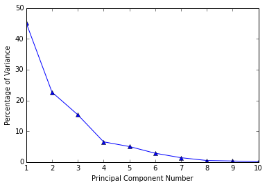

```python
import matplotlib.pyplot as plt
%matplotlib inline

fig = plt.figure()
ax = fig.add_subplot(111)
ax.plot(range(1, 11), varPercentage[:10], marker='^')
plt.xlabel('Principal Component Number')
plt.ylabel('Percentage of Variance')
plt.show()
```

```python
topNfeat = 5
topEigValInd = eigValInd[:topNfeat]  #cut off unwanted dimensions
reducedEigVects = eigVects[:,topEigValInd]   #reorganize eig vects largest to smallest
reducedDT = np.dot(meanRemoved, reducedEigVects)    #transform data into new dimensions
print reducedDT
```

```
[[-25.45  -1.8    4.02  -3.12   0.24]
 [-23.78  -7.29  -0.53  -4.77  -6.32]
 [-15.03  -5.44 -10.09  -3.46  -2.87]
 [ -6.75  -4.39 -14.84  -3.08  -0.44]
 [-46.7    0.01  21.78   3.11   0.29]
 [ 27.41   7.93  12.27 -15.16 -13.47]
 [ 15.67 -21.74  -1.33  11.4   -5.81]
 [  8.28 -16.54  -6.94   5.39  -1.47]
 [ 29.51 -18.64  16.68   4.82   1.69]
 [ 11.41   0.44  15.03  -3.03  17.19]
 [  6.98  37.69   4.5   14.83  -5.5 ]
 [  5.97  13.91  -6.64   2.12   3.32]
 [ 12.36  10.4   -4.93 -11.5    5.51]
 [  1.67   2.69 -13.18  -2.04   3.72]
 [ -1.53   2.79 -15.8    4.49   3.94]]
```

#### Next, let's look at an application of Singular Value Decomposition. This time, we'll foucs on the term-document matrix in order to find themes based on combinations of terms.

```python
u, s, vt = la.svd(TD, full_matrices=False)
```

```python
print u
```

```
[[ 0.39 -0.6   0.22  0.17  0.22 -0.1  -0.59  0.07 -0.07  0.04]
 [ 0.3  -0.2  -0.33 -0.5   0.06 -0.17  0.21 -0.08 -0.57 -0.31]
 [ 0.2   0.16  0.33 -0.16  0.04 -0.4   0.   -0.76  0.23 -0.02]
 [ 0.37  0.27  0.    0.42 -0.49 -0.53  0.04  0.27 -0.16 -0.05]
 [ 0.32  0.23 -0.19  0.49  0.31  0.38  0.03 -0.22  0.   -0.52]
 [ 0.29 -0.23 -0.02  0.   -0.66  0.53  0.07 -0.31 -0.03  0.22]
 [ 0.36  0.38  0.62 -0.35  0.08  0.3   0.02  0.34 -0.1  -0.03]
 [ 0.21  0.05 -0.34 -0.38 -0.2  -0.02 -0.28  0.21  0.65 -0.33]
 [ 0.23 -0.44  0.15  0.11  0.15 -0.09  0.72  0.18  0.38 -0.02]
 [ 0.42  0.25 -0.42 -0.03  0.33  0.    0.02  0.01  0.07  0.68]]
```

```python
print s
```

```
[ 93.97  77.25  54.14  29.74  26.27  19.76  13.75   9.41   7.88   3.88]
```

```python
print np.diag(s)
```

```
[[ 93.97   0.     0.     0.     0.     0.     0.     0.     0.     0.  ]
 [  0.    77.25   0.     0.     0.     0.     0.     0.     0.     0.  ]
 [  0.     0.    54.14   0.     0.     0.     0.     0.     0.     0.  ]
 [  0.     0.     0.    29.74   0.     0.     0.     0.     0.     0.  ]
 [  0.     0.     0.     0.    26.27   0.     0.     0.     0.     0.  ]
 [  0.     0.     0.     0.     0.    19.76   0.     0.     0.     0.  ]
 [  0.     0.     0.     0.     0.     0.    13.75   0.     0.     0.  ]
 [  0.     0.     0.     0.     0.     0.     0.     9.41   0.     0.  ]
 [  0.     0.     0.     0.     0.     0.     0.     0.     7.88   0.  ]
 [  0.     0.     0.     0.     0.     0.     0.     0.     0.     3.88]]
```

```python
originalTD = np.dot(u, np.dot(np.diag(s), vt))
print originalTD
```

```
[[ 24.  32.  12.   6.  43.   2.  -0.   3.   1.   6.   4.   0.   0.   0.   0.]
 [  9.   5.   5.   2.  20.  -0.   1.  -0.  -0.   0.  27.  14.   3.   2.  11.]
 [ -0.   3.  -0.  -0.   3.   7.  12.   4.  27.   4.  -0.   1.  -0.   0.  -0.]
 [  3.  -0.   0.   0.  -0.  16.   0.   2.  25.  23.   7.  12.  21.   3.   2.]
 [  1.  -0.  -0.  -0.  -0.  33.   2.  -0.   7.  12.  14.   5.  12.   4.   0.]
 [ 12.   2.   0.   0.  27.   0.   0.   0.   0.  22.   9.   4.  -0.   5.   3.]
 [ -0.  -0.   0.   0.  -0.  18.  32.  22.  34.  17.  -0.  -0.   0.  -0.  -0.]
 [  1.   0.  -0.   0.   2.   0.  -0.   0.   3.   9.  27.   7.   5.   4.   4.]
 [ 21.  10.  16.   7.  31.  -0.   0.   0.   0.   0.  -0.   0.   0.   1.   0.]
 [  2.  -0.   0.   2.  -0.  27.   4.   2.  11.   8.  33.  16.  14.   7.   3.]]
```

```python
numDimensions = 3
u_ld = u[:, :numDimensions]
sigma = np.diag(s)[:numDimensions, :numDimensions]
vt_ld = vt[:numDimensions, :]
lowRankTD = np.dot(u_ld, np.dot(sigma, vt_ld))
```

```python
np.set_printoptions(precision=2,suppress=True,linewidth=120)
print lowRankTD
```

```
[[ 25.33  22.89  13.5    6.13  45.48  -1.98   1.99   2.79   1.9    7.87   4.6    1.34  -1.82   1.01   2.14]
 [ 10.71   7.37   4.79   2.6   18.7    6.82  -5.26  -3.14  -3.04   6.47  21.6    9.52   6.96   4.02   4.41]
 [  1.46   2.05   0.6    0.29   2.07  10.24  12.93   8.54  19.25   9.57  -2.74  -0.     2.18   0.08  -0.94]
 [  1.25  -0.19  -0.45   0.22   1.03  20.3   10.26   6.46  20.37  14.86  15.49   8.63  10.26   3.55   2.17]
 [  0.3   -1.69  -1.06   0.02  -0.57  18.19   4.81   2.78  13.17  12.03  19.71  10.15  10.88   4.12   3.05]
 [ 12.74  10.59   6.33   3.07  22.51   4.64   0.76   1.09   3.03   7.25  10.81   4.81   3.12   2.17   2.49]
 [  0.58   1.9   -0.08   0.01  -0.06  20.55  25.06  16.42  37.57  18.2   -5.23   0.13   4.68   0.16  -1.94]
 [  2.26  -0.13   0.23   0.54   3.39   9.93  -3.09  -2.23   0.62   5.95  19.64   9.17   8.18   3.73   3.5 ]
 [ 17.34  15.78   9.34   4.21  31.25  -3.21   0.35   1.28  -0.65   4.05   1.88   0.19  -2.16   0.39   1.3 ]
 [  1.34  -2.11  -1.07   0.26   0.94  23.19   1.78   0.66  11.78  14.65  31.61  15.6   15.57   6.33   5.21]]
```

#### The VT matrix can be viewed as the new representation of documents in the lower dimensional space.

```python
print vt_ld
```

```
[[ 0.24  0.18  0.1   0.06  0.41  0.39  0.18  0.12  0.37  0.35  0.41  0.21  0.21  0.09  0.07]
 [-0.34 -0.32 -0.2  -0.08 -0.63  0.33  0.2   0.11  0.36  0.13  0.06  0.07  0.15  0.02 -0.02]
 [ 0.07  0.14  0.06  0.02  0.13 -0.06  0.4   0.27  0.43  0.08 -0.62 -0.26 -0.2  -0.1  -0.12]]
```

#### In information retrieval, a query is compared to documents using vector-space similarity between the query vector and document vectors. In the lower dim. space, this can be achieved by first mapping the query to lower dim. space, and then comparing it to docs in the lower dim. space.

```python
queryVector = np.array([0,0,1,5,4,0,6,0,0,2])
lowDimQuery = np.dot(la.inv(sigma), np.dot(u_ld.T, queryVector))
print lowDimQuery
```

```
[ 0.07  0.07  0.05]
```

```python
# Compute Cosine sim between the query and docs in the lower dimensional space

qNorm = lowDimQuery / la.norm(lowDimQuery)
```

```python
docNorm = np.array([vt_ld[:,i]/la.norm(vt_ld[:,i]) for i in range(len(vt_ld[0]))])
print docNorm
```

```
[[ 0.57 -0.81  0.16]
 [ 0.47 -0.8   0.37]
 [ 0.45 -0.85  0.27]
 [ 0.55 -0.82  0.15]
 [ 0.54 -0.83  0.17]
 [ 0.75  0.64 -0.12]
 [ 0.37  0.41  0.83]
 [ 0.38  0.33  0.86]
 [ 0.55  0.54  0.64]
 [ 0.92  0.33  0.2 ]
 [ 0.55  0.08 -0.83]
 [ 0.61  0.2  -0.77]
 [ 0.64  0.47 -0.61]
 [ 0.64  0.16 -0.75]
 [ 0.53 -0.13 -0.84]]
```

```python
sims = np.dot(qNorm, docNorm.T)
# return indices of the docs in decending order of similarity to the query
simInds = sims.argsort()[::-1]
for i in simInds:
    print "Cosine similarity between Document %d and the query is: %.4f" %(i,sims[i])
```

```
Cosine similarity between Document 8 and the query is: 0.9693
Cosine similarity between Document 9 and the query is: 0.8843
Cosine similarity between Document 6 and the query is: 0.8604
Cosine similarity between Document 5 and the query is: 0.8362
Cosine similarity between Document 7 and the query is: 0.8309
Cosine similarity between Document 12 and the query is: 0.4358
Cosine similarity between Document 13 and the query is: 0.1840
Cosine similarity between Document 11 and the query is: 0.1767
Cosine similarity between Document 10 and the query is: 0.0404
Cosine similarity between Document 1 and the query is: -0.0555
Cosine similarity between Document 0 and the query is: -0.0810
Cosine similarity between Document 3 and the query is: -0.1039
Cosine similarity between Document 14 and the query is: -0.1097
Cosine similarity between Document 4 and the query is: -0.1119
Cosine similarity between Document 2 and the query is: -0.1375
```

```python
centroids_svd, clusters_svd = kMeans.kMeans(vt_ld.T, 3, kMeans.distCosine, kMeans.randCent)
```

```
Iteration  1
Iteration  2
Iteration  3
```

```python
print clusters_svd
```

```
[[ 0.    0.  ]
 [ 0.    0.  ]
 [ 0.    0.  ]
 [ 0.    0.  ]
 [ 0.    0.  ]
 [ 2.    0.05]
 [ 2.    0.01]
 [ 2.    0.01]
 [ 2.    0.  ]
 [ 2.    0.01]
 [ 1.    0.  ]
 [ 1.    0.  ]
 [ 1.    0.  ]
 [ 1.    0.  ]
 [ 1.    0.  ]]
```

```python
print "\t\tCluster0\tCluster1\tCluster2"
for i in range(numDimensions):
    print "Theme %d\t\t%.4f\t\t%.4f\t\t%.4f" %(i,centroids_svd[0][i],centroids_svd[1][i],centroids_svd[2][i])
```

```
		Cluster0	Cluster1	Cluster2
Theme 0		0.1994		0.1982		0.2813
Theme 1		-0.3141		0.0570		0.2243
Theme 2		0.0844		-0.2611		0.2239
```